# UrbanClap Assignment

#### This is the solution to the Assignment 1 for the Business Analytics intern position in UrbanClap, Gurgaon

### Importing the libraries

```python
import numpy as np                                    # For performing operations on numpy arrays
import pandas as pd                                   # For storing and manipulating the dataset
import pickle                                         # For storing the intermediate results
import random                                         # For generating random distributions
import time, datetime, calendar                       # For working with timestamps

import matplotlib.pyplot as plt                       # For plotting the graphs
import seaborn as sns                                 # For generating visualisation
import plotly                                         # For interactive Graphing
plotly.tools.set_credentials_file(
    username='revantg',
    api_key='Oox6fKEY5TPFHc5DSjNF'                    # API Key has been mentioned deliberately for using Plotly
)

from imblearn.over_sampling import SMOTE              # For sampling the unbalanced dataset for classification
from sklearn.preprocessing import LabelEncoder        # For encoding labels to numbers
from sklearn.preprocessing import OneHotEncoder       # For one-hot encoding categorical variables
from sklearn.model_selection import train_test_split  # For Splitting into TrainSet and TestSet
from sklearn.model_selection import RepeatedKFold     # For KFold Cross Validation
from sklearn.model_selection import TimeSeriesSplit   # For CrossValidation of Time-Series Datasets
from sklearn.model_selection import GridSearchCV, RandomizedSearchCV
from sklearn.linear_model import LogisticRegression   # For Logistic Regression
from sklearn.metrics import accuracy_score            # For calculating accuracy
```

```python
from warnings import simplefilter                     # For ignoring Warnings
simplefilter(action='ignore')

pd.set_option('display.max_columns', 500)
```

### Importing the dataset

*This dataset belongs to a company providing home services via online discovery platform.*  
The dataset contains records of 30,940 transactions of 16,711 customers.

- Each row corresponds to one transaction (transaction/order/request will be used interchangeably) placed by a customer tracked by `Transaction_ID` unique to the order placed

#### Fields

- **`Profile ID`** : The unique identity value of each customer. For example, transactions with IDs `BBCHH`, `CHWFD` are placed by the same customer identified through `Profile ID` `1`.
- **`Date Of Booking`** : Date on which customer placed the order.
- **`Date of Service Request`** : Date on which the customer needs the service delivered at his/her house
- **`Slot Of Booking`** : Hour of the service requested date when the customer wants the servie to be served
- **`Source`** : The channel of Customer (eg: Customer came to the app/web via Google, Facebook etc)

```python
df_orig = pd.read_excel("dataset.xlsx",
                   sheet_name = "Data",
                   parse_dates = ['Date_of_Booking', 'Date_of_Service_Requested']
                )

df = df_orig.copy()
```

```python
df.head()
```

|  | Transaction_ID | Profile ID | Date_of_Booking | Date_of_Service_Requested | Source | Slot of Booking (Hour of the Day) |
| --- | --- | --- | --- | --- | --- | --- |
| 0 | BBCHH | 1 | 2018-05-20 | 2018-05-21 | D | 14 |
| 1 | CHWFD | 1 | 2018-09-23 | 2018-09-23 | C | 8 |
| 2 | DYDMF | 2 | 2018-11-10 | 2018-11-13 | C | 11 |
| 3 | EZYSA | 3 | 2018-04-12 | 2018-04-16 | B | 8 |
| 4 | HWAKX | 3 | 2018-08-05 | 2018-08-06 | B | 11 |

### The following queries have been solved in `Python3`

1. ```
   Plot new users acquired every month on a bar chart (New user in a month = a customer who has placed a request for the first time ever)
   ```

2. ```
   30-Day repeat rate is defined as percentage of new users who have placed a 2nd order within 30 days of placing their first order.
   What is the 30-day repeat rate of users acquired in December 2017?
   ```

3. ```
   What is the 90-day repeat rate of users acquired in Jan,Feb,March 2018?
   ```

4. ```
   Use logistic regression to predict the 90-day repeat of users acquired in November 2018.
   ```

5. ```
   Plot the distribution of users by frequency of their 90-day repeat (Number of times user repeated within first 90 days)
   ```

### Solution 1 : Users acquired every month on a bar chart

**1. Finding the first `Date_of_Booking` for every user**

```
grouped_df = df[['Profile ID', 'Date_of_Booking']].groupby([df['Profile ID']]).min()
```

```python
grouped_df = df[['Profile ID', 'Date_of_Booking']].groupby([df['Profile ID']]).min()[['Date_of_Booking']]
grouped_df.rename(columns = {'Date_of_Booking' : 'First_Day_of_Booking'}, inplace = True)
```

**2. Finding the number of new users with respect to every month and year**

```
grouped_df.groupby([grouped_df['First_Day_of_Booking'].dt.year, grouped_df['First_Day_of_Booking'].dt.month_name()]).count()
```

```python
num_of_new_users = grouped_df.groupby(
                                        [
                                            grouped_df['First_Day_of_Booking'].dt.year,
                                            grouped_df['First_Day_of_Booking'].dt.month
                                        ]
                                     ).count()
num_of_new_users.index.names = ['Year Of Booking', 'Month Of Booking']
num_of_new_users.rename(columns = {'First_Day_of_Booking' : "New Users"}, inplace = True)

num_of_new_users.sort_index(by = ['Year Of Booking', 'Month Of Booking'], inplace = True)

num_of_new_users
```

| Year Of Booking | Month Of Booking | New Users |
| --- | --- | --- |
| 2017 | 12 | 2424 |
| 2018 | 1 | 1892 |
|  | 2 | 1549 |
|  | 3 | 1490 |
|  | 4 | 1346 |
|  | 5 | 1264 |
|  | 6 | 1273 |
|  | 7 | 1208 |
|  | 8 | 1120 |
|  | 9 | 1020 |
|  | 10 | 1110 |
|  | 11 | 1015 |

**3. Plotting / Visualising the data for `num_of_new_users` (Number of new users) w.r.t. month and year**

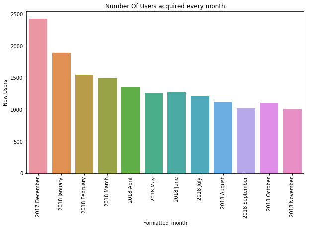

```python
num_of_new_users.reset_index(inplace = True)
num_of_new_users['Formatted_month'] = num_of_new_users['Year Of Booking'].astype(str) + ' ' + \
                                      num_of_new_users['Month Of Booking'].apply(
                                          lambda x : time.strftime("%B", time.strptime(str(x), '%m'))
                                      )

axes = plt.figure(figsize = (10, 6))
ax = sns.barplot(
    x = 'Formatted_month',
    y = 'New Users',
    data = num_of_new_users
)
ax.set_xticklabels(labels = num_of_new_users['Formatted_month'], rotation=90)
ax.set_title('Number Of Users acquired every month')

plt.show()
```

```python
trace0 = plotly.graph_objs.Bar(
    x=num_of_new_users['Formatted_month'],
    y=num_of_new_users['New Users'],
    text = (num_of_new_users['New Users'] / num_of_new_users['New Users'].sum() * 100).round(2).astype(str).values + "% of new-users were acquired this month",
    marker=dict(
        color='rgb(158,202,225)',
        line=dict(
            color='rgb(8,48,107)',
            width=1.5,
        )
    ),
    opacity=0.6
)

data = [trace0]
layout = plotly.graph_objs.Layout(
    title='New Users Acquired every Month',
)

fig = plotly.graph_objs.Figure(data=data, layout=layout)
plotly.plotly.iplot(fig, filename='New Users Acquired every Month')
```

[interactive chart not shown]

```python
# %age changes every month
for i in (np.divide(num_of_new_users['New Users'].values[1:] - num_of_new_users['New Users'].values[:-1],num_of_new_users['New Users'].values[1:]) * 100):
    print(np.round(i, 3), "%age decrease from the previous month")
```

```
-28.118 %age decrease from the previous month
-22.143 %age decrease from the previous month
-3.96 %age decrease from the previous month
-10.698 %age decrease from the previous month
-6.487 %age decrease from the previous month
0.707 %age decrease from the previous month
-5.381 %age decrease from the previous month
-7.857 %age decrease from the previous month
-9.804 %age decrease from the previous month
8.108 %age decrease from the previous month
-9.36 %age decrease from the previous month
```

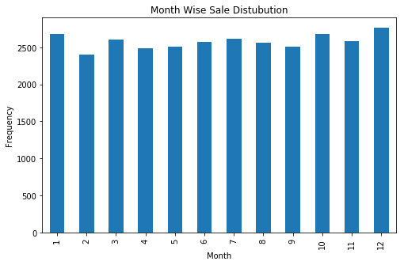

```python
ax = plt.figure(figsize = (8, 5))
plt.title("Month Wise Sale Distubution")
plt.xlabel("Month")
plt.ylabel("Frequency")
df['Date_of_Booking'].dt.month.value_counts().sort_index().plot(kind = 'bar')
```

> **Insights**
> - Number of new users in January 2018 dropped the most ie 28.118 %
> - Number of New Users in May had dropped almost about to 52.14% of sales in Deceember 2017  
>   **However**, the total users engaging on the service remained roughly the same as seen in the above graph

### **Solution 2 : What is the 30-day repeat rate of users acquired in December 2017?**

All of the following statements have been written in a more explanatory manner.  
The code can be compressed to be of 4-5 lines.  
None of the code mentioned below makes use of an explicit `for loop`, thereby maintaining the awesome runtime of `numpy` and `pandas` resulting in an extremely optimised code

**1. Finding the first `Date_of_Booking` for each user**

```python
first_booking_data = df.groupby(['Profile ID'])['Date_of_Booking'].min().to_frame().reset_index()
```

**2. Get user data of users who have their first `Date_of_Booking`'s Month == 12 and `Date_of_Booking`'s Year = 2017**

```python
dec_users_id = first_booking_data[(first_booking_data['Date_of_Booking'].dt.month == 12) & (first_booking_data['Date_of_Booking'].dt.year == 2017)]['Profile ID'].values
dec_users_data = df.loc[df['Profile ID'].isin(dec_users_id)]
dec_users_data.sort_values(['Profile ID', 'Date_of_Booking']).head()
```

|  | Transaction_ID | Profile ID | Date_of_Booking | Date_of_Service_Requested | Source | Slot of Booking (Hour of the Day) |
| --- | --- | --- | --- | --- | --- | --- |
| 8 | BGNZX | 7 | 2017-12-07 | 2017-12-12 | D | 16 |
| 25 | IXAJB | 18 | 2017-12-30 | 2018-01-03 | C | 14 |
| 26 | UVFIY | 18 | 2018-11-06 | 2018-11-07 | C | 13 |
| 35 | RCZNH | 25 | 2017-12-30 | 2018-01-03 | A | 16 |
| 36 | IJJUZ | 25 | 2018-05-14 | 2018-05-15 | D | 14 |

**3. Filtering the users who've booked more than 1 orders**

```python
freq_dec_users = dec_users_data.groupby(['Profile ID']).size()
repeat_dec_users = list(freq_dec_users[freq_dec_users > 1].index)
dec_users_data = df.loc[df['Profile ID'].isin(repeat_dec_users)]
```

```python
a = dec_users_data.groupby(['Profile ID'])['Date_of_Booking'].nsmallest(2).groupby(level = 'Profile ID')
print("30 Day Repeat Rate (for < 30 days)  :", ((a.last() - a.first()).dt.days < 30).sum() * 100 / len(dec_users_id))
print("30 Day Repeat Rate (for <= 30 days) :", ((a.last() - a.first()).dt.days <= 30).sum() * 100 / len(dec_users_id))
```

```
30 Day Repeat Rate (for < 30 days)  : 16.625412541254125
30 Day Repeat Rate (for <= 30 days) : 16.831683168316832
```

### **Solution 3 : What is the 90-day repeat rate of users acquired in Jan, Feb, March 2018?**

Reusing the above code with the following modifications

- `repeat_rate_mon = ['01', '02', '03']`
- `repeat_rate_year = 2018`
- `rep_rate_interval = 90`

```python
repeat_rate_mon, repeat_rate_year = ['01', '02', '03'], [2018]
rep_rate_interval = 90

first_booking_data = df.groupby(['Profile ID'])['Date_of_Booking'].min().to_frame().reset_index()

dec_users_id = first_booking_data[(first_booking_data['Date_of_Booking'].dt.month.isin(repeat_rate_mon)) & (first_booking_data['Date_of_Booking'].dt.year.isin(repeat_rate_year))]['Profile ID'].values
dec_users_data = df.loc[df['Profile ID'].isin(dec_users_id)]
dec_users_data.sort_values(['Profile ID', 'Date_of_Booking']).head()

freq_dec_users = dec_users_data.groupby(['Profile ID']).size()
repeat_dec_users = list(freq_dec_users[freq_dec_users > 1].index)
dec_users_data = df.loc[df['Profile ID'].isin(repeat_dec_users)]

a = dec_users_data.groupby(['Profile ID'])['Date_of_Booking'].nsmallest(2).groupby(level = 'Profile ID')
print("30 Day Repeat Rate (for < 90 days)  :", ((a.last() - a.first()).dt.days < rep_rate_interval).sum() / len(dec_users_id) * 100)
print("30 Day Repeat Rate (for <= 90 days) :", ((a.last() - a.first()).dt.days <= rep_rate_interval).sum() / len(dec_users_id) * 100)
```

```
30 Day Repeat Rate (for < 90 days)  : 20.54350030419793
30 Day Repeat Rate (for <= 90 days) : 20.74629892516731
```

### **Solution 4 : Predict the 90-day repeat of users acquired in November 2018 using Logistic Regression**

**1.** Finding the indexes of rows containing the record of All Users's first booking.  
**2.** Selecting the above acquired indexes to get their record of first purchase/use of service.

```python
vals = df.groupby(['Profile ID'])['Date_of_Booking'].idxmin().values
profile_booking_data = df.loc[vals]
```

**3.** Finding the number of purchases of each user.  
**4.** Filtering in the users whose number of purchases > 1.  
**5.** Finding the `first_date_of_booking` for each of the above filtered users.  
**6.** Finding the `second_date_of_booking` for each of the above filtered users.  
**7.** Filtering the users whose difference between `second_date_of_booking` and `second_date_of_booking`

- `second_date_of_booking - first_date_of_booking < 90`

```python
grouped_df = df[['Profile ID', 'Date_of_Booking']].groupby(['Profile ID']).size().to_frame().rename(columns = {0 : 'No. of times shopped'})

repeat_users = list(grouped_df[grouped_df['No. of times shopped'] > 1].index)
repeat_users_data = df.loc[df['Profile ID'].isin(repeat_users), ['Profile ID', 'Date_of_Booking']]

first_two_dates_of_booking_df =  repeat_users_data[['Profile ID', 'Date_of_Booking']].groupby(['Profile ID'])['Date_of_Booking'].nsmallest(2).groupby(level = 'Profile ID')
first_date_of_booking = first_two_dates_of_booking_df.first()
second_date_of_booking = first_two_dates_of_booking_df.last()

repeat_rate = ((second_date_of_booking - first_date_of_booking).dt.days < rep_rate_interval)
repeat_users = repeat_rate[repeat_rate].index.tolist()
```

**8.** Displaying the data for each users  
**9.** Adding the column `repeat_within_90_days`

- `repeat_within_90_days` is set to `0` if user did not place a second order within 90 days
- `repeat_within_90_days` is set to `1` if user placed a second order within 90 days

```python
profile_booking_data.set_index('Profile ID', inplace = True)
profile_booking_data['repeat_within_90_days'] = 0
profile_booking_data.loc[repeat_users, 'repeat_within_90_days'] = 1

train_df = profile_booking_data.copy()
train_df = train_df.reset_index().drop(columns = ['Profile ID'])
train_df.head()
```

|  | Transaction_ID | Date_of_Booking | Date_of_Service_Requested | Source | Slot of Booking (Hour of the Day) | repeat_within_90_days |
| --- | --- | --- | --- | --- | --- | --- |
| 0 | BBCHH | 2018-05-20 | 2018-05-21 | D | 14 | 0 |
| 1 | DYDMF | 2018-11-10 | 2018-11-13 | C | 11 | 0 |
| 2 | EZYSA | 2018-04-12 | 2018-04-16 | B | 8 | 0 |
| 3 | YRKFO | 2018-03-02 | 2018-03-05 | A | 13 | 0 |
| 4 | JSFWY | 2018-01-06 | 2018-01-07 | C | 14 | 0 |

1. Calculating Gap  
   `Gap` is difference between `Date_of_Service_Requested` and `Date_of_Booking`

```python
num_of_orders = df[['Date_of_Booking', 'Profile ID']].groupby('Profile ID')['Date_of_Booking'].size()
new_users = num_of_orders[num_of_orders == 1].index

new_user_data = df.loc[df['Profile ID'].isin(num_of_orders[num_of_orders == 1].index)]
test_data_orig = new_user_data.loc[(new_user_data['Date_of_Booking'].dt.month == 11) & (new_user_data['Date_of_Booking'].dt.year == 2018)]

test_df = test_data_orig.copy()
test_df['repeat_within_90_days'] = [2] * test_df.shape[0]
test_df.drop(columns = ['Profile ID'], inplace = True)
test_df.head()
```

|  | Transaction_ID | Date_of_Booking | Date_of_Service_Requested | Source | Slot of Booking (Hour of the Day) | repeat_within_90_days |
| --- | --- | --- | --- | --- | --- | --- |
| 2 | DYDMF | 2018-11-10 | 2018-11-13 | C | 11 | 2 |
| 29 | QIYRA | 2018-11-27 | 2018-11-27 | B | 8 | 2 |
| 124 | KGYWP | 2018-11-11 | 2018-11-12 | C | 14 | 2 |
| 158 | QFPHG | 2018-11-04 | 2018-11-06 | D | 6 | 2 |
| 173 | UNMBP | 2018-11-22 | 2018-11-23 | D | 10 | 2 |

```python
all_df = pd.concat([train_df, test_df], axis = 0)
```

Feature Engineering

- `Gap` is difference between `Date_of_Service_Requested` and `Date_of_Booking`
- `Date_of_Service_Requested_dayofweek` is the day-of-week for `Date_of_Service_Requested`
- `Date_of_Booking_dayofweek` is the day-of-week for `Date_of_Booking`

```python
all_df['Gap'] = (all_df['Date_of_Service_Requested'] - all_df['Date_of_Booking']).dt.days
all_df['Date_of_Service_Requested_dayofweek'] = all_df['Date_of_Service_Requested'].dt.day_name()
all_df['Date_of_Booking_dayofweek'] = all_df['Date_of_Booking'].dt.day_name()
```

1. Processing the training data

```python
all_df.tail()
```

|  | Transaction_ID | Date_of_Booking | Date_of_Service_Requested | Source | Slot of Booking (Hour of the Day) | repeat_within_90_days | Gap | Date_of_Service_Requested_dayofweek | Date_of_Booking_dayofweek |
| --- | --- | --- | --- | --- | --- | --- | --- | --- | --- |
| 30727 | MKCNH | 2018-11-23 | 2018-11-24 | B | 14 | 2 | 1 | Saturday | Friday |
| 30854 | SUAQY | 2018-11-09 | 2018-11-09 | B | 14 | 2 | 0 | Friday | Friday |
| 30858 | MPLRD | 2018-11-19 | 2018-11-23 | D | 14 | 2 | 4 | Friday | Monday |
| 30859 | AYBAL | 2018-11-30 | 2018-12-02 | C | 6 | 2 | 2 | Sunday | Friday |
| 30915 | BPNYR | 2018-11-13 | 2018-11-17 | C | 11 | 2 | 4 | Saturday | Tuesday |

One-Hot-Encoding the categorical variables

```
Source,
Slot of Booking (Hour of the Day),
Date_of_Service_Requested_dayofweek,
Date_of_Booking_dayofweek,
Gap
```

Gap has been added as a categorical variable as it improves accuracy

```python
train_test_df = pd.get_dummies(data = all_df, columns = ['Source', 'Slot of Booking (Hour of the Day)', 'Date_of_Service_Requested_dayofweek', 'Date_of_Booking_dayofweek', 'Gap'], prefix = ['Source_', 'Slot of Booking (Hour of the Day)_', 'Date_of_Service_Requested_dayofweek_', 'Date_of_Booking_dayofweek_', 'Gap_'], drop_first = True)
train_test_df.head()
```

|  | Transaction_ID | Date_of_Booking | Date_of_Service_Requested | repeat_within_90_days | Source__B | Source__C | Source__D | Slot of Booking (Hour of the Day)__7 | Slot of Booking (Hour of the Day)__8 | Slot of Booking (Hour of the Day)__9 | Slot of Booking (Hour of the Day)__10 | Slot of Booking (Hour of the Day)__11 | Slot of Booking (Hour of the Day)__12 | Slot of Booking (Hour of the Day)__13 | Slot of Booking (Hour of the Day)__14 | Slot of Booking (Hour of the Day)__15 | Slot of Booking (Hour of the Day)__16 | Slot of Booking (Hour of the Day)__17 | Slot of Booking (Hour of the Day)__18 | Slot of Booking (Hour of the Day)__19 | Date_of_Service_Requested_dayofweek__Monday | Date_of_Service_Requested_dayofweek__Saturday | Date_of_Service_Requested_dayofweek__Sunday | Date_of_Service_Requested_dayofweek__Thursday | Date_of_Service_Requested_dayofweek__Tuesday | Date_of_Service_Requested_dayofweek__Wednesday | Date_of_Booking_dayofweek__Monday | Date_of_Booking_dayofweek__Saturday | Date_of_Booking_dayofweek__Sunday | … |
| --- | --- | --- | --- | --- | --- | --- | --- | --- | --- | --- | --- | --- | --- | --- | --- | --- | --- | --- | --- | --- | --- | --- | --- | --- | --- | --- | --- | --- | --- | --- |
| 0 | BBCHH | 2018-05-20 | 2018-05-21 | 0 | 0 | 0 | 1 | 0 | 0 | 0 | 0 | 0 | 0 | 0 | 1 | 0 | 0 | 0 | 0 | 0 | 1 | 0 | 0 | 0 | 0 | 0 | 0 | 0 | 1 | … |
| 1 | DYDMF | 2018-11-10 | 2018-11-13 | 0 | 0 | 1 | 0 | 0 | 0 | 0 | 0 | 1 | 0 | 0 | 0 | 0 | 0 | 0 | 0 | 0 | 0 | 0 | 0 | 0 | 1 | 0 | 0 | 1 | 0 | … |
| 2 | EZYSA | 2018-04-12 | 2018-04-16 | 0 | 1 | 0 | 0 | 0 | 1 | 0 | 0 | 0 | 0 | 0 | 0 | 0 | 0 | 0 | 0 | 0 | 1 | 0 | 0 | 0 | 0 | 0 | 0 | 0 | 0 | … |
| 3 | YRKFO | 2018-03-02 | 2018-03-05 | 0 | 0 | 0 | 0 | 0 | 0 | 0 | 0 | 0 | 0 | 1 | 0 | 0 | 0 | 0 | 0 | 0 | 1 | 0 | 0 | 0 | 0 | 0 | 0 | 0 | 0 | … |
| 4 | JSFWY | 2018-01-06 | 2018-01-07 | 0 | 0 | 1 | 0 | 0 | 0 | 0 | 0 | 0 | 0 | 0 | 1 | 0 | 0 | 0 | 0 | 0 | 0 | 0 | 1 | 0 | 0 | 0 | 0 | 1 | 0 | … |

Splitting the `train_test_df` into `training_df` and `testing_df`

```python
training_df = train_test_df[train_test_df['repeat_within_90_days'] != 2]
testing_df = train_test_df[train_test_df['repeat_within_90_days'] == 2]

x = datetime.datetime.strptime("2018-September", "%Y-%B")
training_df = training_df[training_df['Date_of_Booking'] < x]

training_df.drop(columns = ['Transaction_ID', 'Date_of_Booking', 'Date_of_Service_Requested'], inplace = True)
testing_df.drop(columns = ['Transaction_ID', 'Date_of_Booking', 'Date_of_Service_Requested'], inplace = True)
```

### Building the model

Getting the `dependent` and `independent` variables

```python
X = training_df.iloc[:, 1:].values
y = training_df.iloc[:, 0].values

X_train, X_test, y_train, y_test = train_test_split(X, y, test_size=0.2, random_state=42)
```

There is a need of upsampling the minority class which is unbalanced in the dataset ( 22.77% )

```
SMOTE synthesises new minority instances between existing (real) minority instances.
```

Upsampling the minority instances

```python
sm = SMOTE(random_state=2)
X_train, y_train = sm.fit_sample(X_train, y_train.ravel())
```

Building the `Logistic Regression` Base Model without any parameters

```python
model = LogisticRegression()
model.fit(X_train, y_train)

print(accuracy_score(model.predict(X_test), y_test))
```

```
0.7682387619749448
```

Optimizing the Logistic Regression by finding the right set of parameters using GridSearchCV

```
param_grid = {
    'penalty' : ['l1', 'l2'],
    'tol' : np.geomspace(0.01, 0.0000001, 20),
    'C' : np.arange(0.5, 5, 0.2),
    'fit_intercept' : [True, False]
}
```

```python
lc = LogisticRegression(n_jobs = -1)

param_grid = {
    'penalty' : ['l1', 'l2'],
    'tol' : np.geomspace(0.01, 0.0000001, 20),
    'C' : np.arange(0.5, 5, 0.2),
    'fit_intercept' : [True, False]
}

clf = GridSearchCV(lc, param_grid, cv=5, n_jobs=-1, verbose = 2)
clf.fit(X_train, y_train)

print("Best Possible Score in the randomized dataset:", clf.best_score_)
print("Best Parameters :", clf.best_params_)
```

```
Fitting 5 folds for each of 1840 candidates, totalling 9200 fits
```

```
[Parallel(n_jobs=-1)]: Using backend LokyBackend with 4 concurrent workers.
[Parallel(n_jobs=-1)]: Done  38 tasks      | elapsed:    1.9s
[Parallel(n_jobs=-1)]: Done 516 tasks      | elapsed:   13.0s
[Parallel(n_jobs=-1)]: Done 1328 tasks      | elapsed:   31.8s
[Parallel(n_jobs=-1)]: Done 2460 tasks      | elapsed:   57.6s
[Parallel(n_jobs=-1)]: Done 3920 tasks      | elapsed:  1.5min
[Parallel(n_jobs=-1)]: Done 5700 tasks      | elapsed:  2.2min
[Parallel(n_jobs=-1)]: Done 7808 tasks      | elapsed:  3.0min
```

```
Best Possible Score in the randomized dataset: 0.6764107203437747
Best Parameters : {'C': 2.8999999999999995, 'fit_intercept': True, 'penalty': 'l1', 'tol': 0.0008858667904100832}
```

```
[Parallel(n_jobs=-1)]: Done 9200 out of 9200 | elapsed:  3.6min finished
```

Additional CrossValidation using `RepeatedKFold`

```python
kf = RepeatedKFold(n_splits=5, n_repeats=10, random_state=None)

X = training_df.iloc[:, 1:].values
y = training_df.iloc[:, 0].values

sm = SMOTE(random_state=2)
X, y = sm.fit_sample(X, y)

scores = []

for train_index, test_index in kf.split(X):
    X_train, X_test = X[train_index], X[test_index]
    y_train, y_test = y[train_index], y[test_index]

    lc = LogisticRegression(C = 2.01, fit_intercept = True, penalty = 'l1')
    lc.fit(X_train, y_train)

    scores.append(accuracy_score(lc.predict(X_test), y_test))

print("\nAverage accuracy_score :", np.mean(scores).round(5) * 100)
```

```
Average accuracy_score : 64.899
```

**Making Predictions**  
Predicting the values for test-set

```python
X = training_df.iloc[:, 1:].values
y = training_df.iloc[:, 0].values

sm = SMOTE(random_state=2)
X, y = sm.fit_sample(X, y)

lc = LogisticRegression(C = 2.01, fit_intercept = True, penalty = 'l1')
lc.fit(X, y)

testing_X = testing_df.iloc[:, 1:].values
testing_y = lc.predict(testing_X)
```

```python
testing_y_dist = pd.Series(testing_y).value_counts()
print("Predicted 90 day rate :", testing_y_dist[1] * 100 / testing_y_dist.sum())
```

```
Predicted 90 day rate : 25.254237288135593
```

### Solution 5 : Plot the distribution of users by frequency of their 90-day repeat

1. Group by Profile ID and finding the number of times new users who placed their second order before 90 days of placing their first Order

   ```
   df[['Profile ID', 'Date_of_Booking']].groupby(['Profile ID'])['Date_of_Booking'].apply(lambda x: ((x - min(x)).dt.days < 90).sum())
   ```

```python
number_of_used_within_90days = df[['Profile ID', 'Date_of_Booking']].groupby(['Profile ID'])['Date_of_Booking'].apply(lambda x: ((x - min(x)).dt.days < 90).sum())
number_of_used_within_90days = number_of_used_within_90days.to_frame().rename(columns = {'Date_of_Booking' : 'Number of uses within 90 days'})
number_of_used_within_90days.head()
```

| Profile ID | Number of uses within 90 days |
| --- | --- |
| 1 | 1 |
| 2 | 1 |
| 3 | 1 |
| 4 | 1 |
| 5 | 1 |

**2. Plotting Using Seaborn**

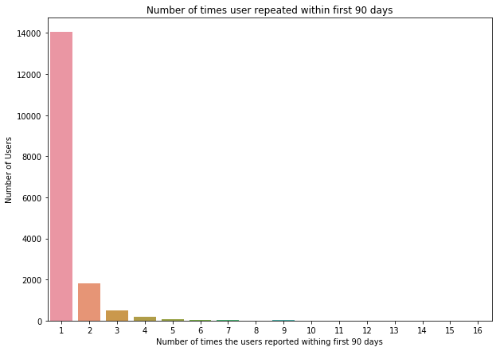

```python
freq = number_of_used_within_90days['Number of uses within 90 days']

ax = plt.figure(figsize = (10, 7))
cplot = sns.barplot(
    x = freq.value_counts().sort_index().index,
    y = freq.value_counts().sort_index().values
)

cplot.set_xticklabels(freq.index)
cplot.set_title('Number of times user repeated within first 90 days')

cplot.set(xlabel='Number of times the users reported withing first 90 days',
          ylabel='Number of Users')

plt.show()
```

**3. Plotting Using Plotly for more interactivity**

```python
trace0 = plotly.graph_objs.Bar(
    x=freq.value_counts().sort_index().index,
    y=freq.value_counts().sort_index().values,
    marker=dict(
        color='rgb(158,202,225)',
        line=dict(
            color='rgb(8,48,107)',
            width=1.5,
        )
    ),
    opacity=0.6
)

data = [trace0]
layout = plotly.graph_objs.Layout(
    title='Distribution of frequency',
)

fig = plotly.graph_objs.Figure(data=data, layout=layout)
plotly.plotly.iplot(fig, filename='Distribution_of_frequency')
```

[interactive chart not shown]

## Alternative Solution to Problem 2 and 3

```python
users = {}
for i, row in df.iterrows():
    if row['Profile ID'] not in users:
        users[row['Profile ID']] = [row['Date_of_Booking']]
    else:
        users[row['Profile ID']] += [row['Date_of_Booking']]

for i in users:
    users[i].sort()

c=0
tc = 0
for i in users:
    if users[i][0].month == 12 and users[i][0].year == 2017:
        tc += 1
        if len(users[i]) > 1 and (users[i][1] - users[i][0]).days <= 30:
            c+= 1
print("Solution 2 :", c/tc * 100)

c=0
tc = 0
for i in users:
    if users[i][0].month in [1, 2, 3]:
        tc += 1
        if len(users[i]) > 1 and (users[i][1] - users[i][0]).days <= 90:
            c+=1
print("Solution 3:", c/tc * 100)
```

```
Solution 2 : 16.831683168316832
Solution 3: 20.74629892516731
```

# Some Useful Insights

### Distribution of 90 Day Repeat Rate (month-wise)

```python
formatted_months = []
day_repeat_rates = []

for month in [12] + list(np.arange(1, 8)):

    if month == 12:year = 2017
    else: year = 2018

    repeat_rate_mon, repeat_rate_year = [month], [year]
    rep_rate_interval = 90

    first_booking_data = df.groupby(['Profile ID'])['Date_of_Booking'].min().to_frame().reset_index()

    dec_users_id = first_booking_data[(first_booking_data['Date_of_Booking'].dt.month.isin(repeat_rate_mon)) & (first_booking_data['Date_of_Booking'].dt.year.isin(repeat_rate_year))]['Profile ID'].values
    dec_users_data = df.loc[df['Profile ID'].isin(dec_users_id)]
    dec_users_data.sort_values(['Profile ID', 'Date_of_Booking']).head()

    freq_dec_users = dec_users_data.groupby(['Profile ID']).size()
    repeat_dec_users = list(freq_dec_users[freq_dec_users > 1].index)
    dec_users_data = df.loc[df['Profile ID'].isin(repeat_dec_users)]

    a = dec_users_data.groupby(['Profile ID'])['Date_of_Booking'].nsmallest(2).groupby(level = 'Profile ID')

    day_repeat_rates.append(((a.last() - a.first()).dt.days <= rep_rate_interval).sum() / len(repeat_dec_users))
    formatted_months.append(time.strftime("%B", time.strptime(str(month), '%m')) + f" {year}")
    print(f"90 Day Repeat Rate for {formatted_months[-1]} = {day_repeat_rates[-1]}")


trace0 = plotly.graph_objs.Bar(
    x=formatted_months,
    y=day_repeat_rates,
    marker=dict(
        color='rgb(158,202,225)',
        line=dict(
            color='rgb(8,48,107)',
            width=1.5,
        )
    ),
    opacity=0.6
)

data = [trace0]
layout = plotly.graph_objs.Layout(
    title='90 Day Repeat Rates',
)

fig = plotly.graph_objs.Figure(data=data, layout=layout)
plotly.plotly.iplot(fig, filename='90 Day Repeat Rates')
```

```
90 Day Repeat Rate for December 2017 = 0.5782060785767235
90 Day Repeat Rate for January 2018 = 0.5461077844311377
90 Day Repeat Rate for February 2018 = 0.5081699346405228
90 Day Repeat Rate for March 2018 = 0.4951644100580271
90 Day Repeat Rate for April 2018 = 0.5139664804469274
90 Day Repeat Rate for May 2018 = 0.5641891891891891
90 Day Repeat Rate for June 2018 = 0.5943775100401606
90 Day Repeat Rate for July 2018 = 0.676923076923077
```

[interactive chart not shown]

> **Insight**
> - 90 Day repeat rates showed a mild decline during the Spring season of 2018

### Gap between the `Date of Booking` and `Date of Service`

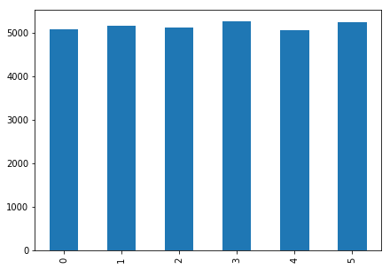

```python
ax = plt.figure(figsize = (7, 5))
(df['Date_of_Service_Requested'] - df['Date_of_Booking']).dt.days.value_counts().sort_index().plot(kind = 'bar')
```

> **Insight**  
> Gaps are more or less uniform. Nothing special here.

### Most Preferred Source

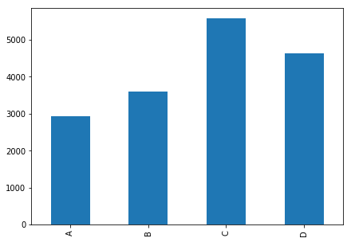

```python
ax = plt.figure(figsize = (7, 5))
df[['Profile ID', 'Source']].groupby('Profile ID')['Source'].apply(lambda x : x.value_counts().index[0]).value_counts().sort_index().plot(kind = 'bar')
```

```python
df[['Profile ID', 'Source']].groupby('Profile ID')['Source'].apply(lambda x : x.value_counts().index[0]).value_counts().sort_index()
```

```
A    2920
B    3600
C    5568
D    4623
Name: Source, dtype: int64
```

### Distribution Of `Date_of_Booking` wrt day

```python
booking_date_distribution = df['Date_of_Booking'].dt.dayofweek.value_counts()

trace0 = plotly.graph_objs.Bar(
    x=list(calendar.day_name),
    y=booking_date_distribution.values,
    marker=dict(
        color='rgb(158,202,225)',
        line=dict(
            color='rgb(8,48,107)',
            width=1.5,
        )
    ),
    opacity=0.6
)

data = [trace0]
layout = plotly.graph_objs.Layout(
    title='DayWise Distribution of Date Of Booking',
)

fig = plotly.graph_objs.Figure(data=data, layout=layout)
plotly.plotly.iplot(fig, filename='DayWise Distribution of Date Of Booking')
```

[interactive chart not shown]

> **INSIGHT**  
> Distribution of Orders on all weekdays is a Uniform Distribution

### Distribution Of `Date_of_Service` wrt day

```python
service_date_distribution = df['Date_of_Service_Requested'].dt.dayofweek.value_counts()

trace0 = plotly.graph_objs.Bar(
    x=list(calendar.day_name),
    y=service_date_distribution.values,
    marker=dict(
        color='rgb(158,202,225)',
        line=dict(
            color='rgb(8,48,107)',
            width=1.5,
        )
    ),
    opacity=0.6
)

data = [trace0]
layout = plotly.graph_objs.Layout(
    title='Distribution Of Date_of_Service wrt day',
)

fig = plotly.graph_objs.Figure(data=data, layout=layout)
plotly.plotly.iplot(fig, filename='Distribution Of Date_of_Service wrt day')
```

[interactive chart not shown]

```python
df['Morning']   = 0       # From 6 to 12
df['Afternoon'] = 0       # From 12 - 16
df['Evening']   = 0       # From 16+

df.loc[df['Slot of Booking (Hour of the Day)'].between(6, 12, inclusive = True), 'Morning'] = 1
df.loc[df['Slot of Booking (Hour of the Day)'].between(13, 16, inclusive = True), 'Afternoon'] = 1
df.loc[df['Slot of Booking (Hour of the Day)'] >= 17, 'Evening'] = 1

trace0 = plotly.graph_objs.Bar(
    x=['Morning', 'Afternoon', 'Evening'],
    y= [df['Morning'].sum(), df['Afternoon'].sum(), df['Evening'].sum()],
    marker=dict(
        color='rgb(158,202,225)',
        line=dict(
            color='rgb(8,48,107)',
            width=1.5,
        )
    ),
    opacity=0.6
)

data = [trace0]
layout = plotly.graph_objs.Layout(
    title='Distribution of slots',
)

fig = plotly.graph_objs.Figure(data=data, layout=layout)
plotly.plotly.iplot(fig, filename='Distribution_of_slots1')
```

[interactive chart not shown]

> **INSIGHT**  
> Roughly, 58.83% users chose their slots in Afternoon

```python
freq_slots = df['Slot of Booking (Hour of the Day)'].value_counts().sort_index()

trace0 = plotly.graph_objs.Bar(
    x=freq_slots.index,
    y= freq_slots.values,
    marker=dict(
        color='rgb(158,202,225)',
        line=dict(
            color='rgb(8,48,107)',
            width=1.5,
        )
    ),
    opacity=0.6
)

data = [trace0]
layout = plotly.graph_objs.Layout(
    title='Distribution of slots',
)

fig = plotly.graph_objs.Figure(data=data, layout=layout)
plotly.plotly.iplot(fig, filename='Distribution-of-slots')
```

[interactive chart not shown]

> **INSIGHT** Roughly 38.83% of users chose the slot of 2PM

## Closing Note

> I would like to express my appreciation for considering me to be a part of the internship technical round.  
> I hope you like this small sampling of my work.  
> I **SINCERELY** want to work with a company as good as UrbanClap  
> I look forward to create many such documents and more with your team

> **Please** get in touch just in case if you think I missed anyhting at the below contact details
> - Phone - `+91-9871966592 (WhatsApp Active)`
> - EMail - `revantgupta2@gmail.com`
> - LinkedIN - `https://www.linkedin.com/in/revantg/`
> - Twitter - `https://twitter.com/revant_g`